# Visualización de datos

**¿Qué es la visualización de datos?**

Mapear valores a visuales o volver números en imágenes e historias.

La información visual es más fácil de procesar.

Es un arte y una ciencia. La ciencia está en el proceso de generar la visualización.

Tu mejor conocimiento es solo tan valioso como tu capacidad para comunicarlo.

**Tipos de visualización en ciencia de datos**

- Exploratoria
  - Relación entre analista y los datos
  - Entender los datos y su contexto
  - Conectar y relacionar
  - Hipótesis alternativas
  - Obtener conocimiento
  - Evitar sesgos
- Explicativa
  - Relación entre analista y el público
  - Comunicar un mensaje
  - Entender el contexto de la audiencia
  - Seleccionar herramientas visuales
  - Eliminar desorden visual
  - Dirigir atención al conocimiento obtenido
  - Crear historias

## Cuarteto de Anscombe

[figure not shown]

Los cuatro conjuntos de datos tienen las mismas medidas estadísticas

- Media x: 9.0
- Varianza x: 11.0
- Media y: 7.5
- Varianza y: 4.12
- Correlación x e y: 0.816
- Recta de regresión: $y = 3 + 0.5 x$

[figure not shown]

Se obtuvo:

- Año de registro (2010-2023)
- Entidad y municipio de ocurrencia
- Lista de tabulación 1 para mortalidad de la CIE
- Sexo
- Edad (grupo)

Lo primero que haremos será cargar los datos para poder verlos.

- ¿Cuántas filas y columnas hay?
- ¿Qué representa cada columna?
- ¿Qué representa cada fila?

```python
import pandas as pd
import matplotlib.pyplot as plt

from google.colab import drive
drive.mount('/content/drive/')

in_dir = "drive/MyDrive/DefuncionesINEGI_2010a2023/"
df = pd.read_csv(in_dir+'data_raw/defuncion_nacion.csv')
df
```

|  | Año | Clave | Entidad | Edad | Sexo | Diagnostico | Frecuencia |
| --- | --- | --- | --- | --- | --- | --- | --- |
| 0 | 2014 | 1 | Aguascalientes | Menores de 1 año | Hombre | Ciertas enfermedades infecciosas y parasitarias | 7 |
| 1 | 2014 | 1 | Aguascalientes | Menores de 1 año | Mujer | Ciertas enfermedades infecciosas y parasitarias | 2 |
| 2 | 2014 | 1 | Aguascalientes | Menores de 1 año | No especificado | Ciertas enfermedades infecciosas y parasitarias | 0 |
| 3 | 2014 | 1 | Aguascalientes | 1-4 años | Hombre | Ciertas enfermedades infecciosas y parasitarias | 1 |
| 4 | 2014 | 1 | Aguascalientes | 1-4 años | Mujer | Ciertas enfermedades infecciosas y parasitarias | 0 |
| ... | ... | ... | ... | ... | ... | ... | ... |
| 472013 | 2015 | 34 | Extranjero | 65-69 años | Mujer | Causas externas de morbilidad y de mortalidad | 0 |
| 472014 | 2015 | 34 | Extranjero | 70-74 años | Hombre | Causas externas de morbilidad y de mortalidad | 0 |
| 472015 | 2015 | 34 | Extranjero | 70-74 años | Mujer | Causas externas de morbilidad y de mortalidad | 0 |
| 472016 | 2015 | 34 | Extranjero | 75-79 años | Hombre | Causas externas de morbilidad y de mortalidad | 0 |
| 472017 | 2015 | 34 | Extranjero | 80-84 años | Mujer | Causas externas de morbilidad y de mortalidad | 0 |

472018 rows × 7 columns

## Conjuntos de datos ordenados

Los principios de los **datos ordenados** (tidy data) proporcionan una forma estándar de organizar los valores de datos dentro de un conjunto de datos. Un estándar hace que la limpieza inicial de datos sea más fácil, ya que no es necesario empezar desde cero y reinventar la rueda cada vez. El estándar de datos ordenados ha sido diseñado para facilitar la exploración inicial y el análisis de los datos, y para simplificar el desarrollo de herramientas de análisis de datos que funcionen bien juntas. Estos principios fueron dados por Hadley Wickham ([artículo original](http://vita.had.co.nz/papers/tidy-data.pdf)).

Una **variable** es una medida o un atributo que puede ser asignado a un objeto o individuo. Por ejemplo, la edad, el peso, la altura, el género, la fecha de nacimiento, etc. son variables que pueden ser asignadas a una persona. Una variable puede ser cuantitativa (en la que los valores pueden ser medidos en una escala numérica) o cualitativa (en la que los valores son categóricos, es decir, no pueden ser medidos en una escala numérica). En ambos casos, la variable se utiliza para describir algo y para analizar datos.

Un **valor** es una medida o atributo específico asociado a una variable. Por ejemplo, si una variable es la fecha de nacimiento, un valor podría ser 10 de mayo. Si la variable es el peso, un valor podría ser 80 kg. Los valores son los valores concretos o específicos asociados con una variable en un momento dado.

Una **observación** es una serie de medida o registro de una variable o atributo en un momento o en una unidad específica. Por ejemplo, la observación de la altura y peso de una persona en un momento específico. En un estudio o experimento, las observaciones se recopilan y se utilizan para extraer información y conclusión sobre la relación entre variables o para describir una población o un fenómeno.

Un **dato** es una unidad de información, ya sea numérica o categórica, que se recolecta para describir o medir un fenómeno o una característica de un objeto o sujeto. Por ejemplo, la edad, el género, la estatura, el peso, la fecha de nacimiento, entre otros, son datos que se pueden recopilar sobre una persona. Los datos se utilizan para analizar patrones y tendencias, tomar decisiones basadas en información y generar conocimientos nuevos a partir de la información existente.

## Tipos de datos

Existen varios tipos de datos:

- Númericos: valores contables discretos o continuos
- Binarios: verdadero o falso
- Categoricos: número limitado de categorias
- Texto
- Otros: Fecha, Coordenadas, etc

Los datos no siempre están completos, es decir, a veces desconocemos el valor de un dato. Esto se puede representar de varias formas. En el caso de pandas se usa NaN para representar los datos faltantes o desconocidos.

Al cargar un conjunto de datos es importante asegurarse que cada columna (variable) este en el formato adecuado.

```python
from pandas.api.types import CategoricalDtype

df = pd.read_csv(in_dir+'/data_raw/defuncion_nacion.csv', dtype=str)

# Año
df['Año'] = df['Año'].apply(lambda x: int(x))
# Edad
cat_edad = list( df['Edad'].unique() )
cat_edad = CategoricalDtype(categories=cat_edad, ordered=True)
df['Edad'] = df['Edad'].astype(cat_edad)
# Diagnostico: desgloce respiratorias
diag_resp = ['Influenza (gripe)', 'Neumonía',
       'Otras infecciones agudas de las vías respiratorias inferiores',
       'Enfermedades crónicas de las vías respiratorias inferiores',
       'Resto de enfermedades del sistema respiratorio']
df_resp = df[df['Diagnostico'].isin(diag_resp)]
df = df[~df['Diagnostico'].isin(diag_resp)]
# Sexo
df['Sexo'] = df['Sexo'].astype('category')
# Frecuencia
df['Frecuencia'] = df['Frecuencia'].apply(lambda x: int(x))

df.dtypes
```

|  | 0 |
| --- | --- |
| Año | int64 |
| Clave | object |
| Entidad | object |
| Edad | category |
| Sexo | category |
| Diagnostico | object |
| Frecuencia | int64 |

**dtype:** object

## Profile de datos

Un **profiler de datos** en Python es una herramienta o librería que se utiliza para analizar y generar un informe detallado sobre las características de un conjunto de datos. Su propósito principal es ayudar a los usuarios a comprender mejor los datos con los que están trabajando. Esto incluye información sobre la estructura, calidad y distribución de los datos, como:

- **Resumen estadístico** de las columnas: media, mediana, moda, desviación estándar, etc.
- **Valores faltantes**: cuántos valores faltan en cada columna.
- **Distribución de datos**: cómo se distribuyen los valores en las columnas.
- **Valores atípicos (outliers)**: si hay valores que se desvían significativamente del resto.
- **Tipos de datos**: qué tipos de datos (numéricos, categóricos, fechas) están presentes.
- **Correlaciones**: análisis de correlación entre variables.

Estas herramientas son muy útiles para realizar un **análisis exploratorio de datos (EDA)** y comprender el estado inicial de un dataset antes de realizar tareas más avanzadas, como la limpieza de datos o el modelado.

## Gráfica: Defunciones por año

Queremos ver la relación de cada variable (Año, Edad, Sexo, etc) con la frecuencia.

Iremos de lo sencillo a lo complicado. Primero separemos una variable y la frecuencia.

Agrupemos sumando la frecuencia por año.

```python
df_año = df[['Año','Frecuencia']].groupby('Año').sum()
df_año
```

| Año | Frecuencia |
| --- | --- |
| 2010 | 592018 |
| 2011 | 590693 |
| 2012 | 602354 |
| 2013 | 623599 |
| 2014 | 633641 |
| 2015 | 655688 |
| 2016 | 685766 |
| 2017 | 703047 |
| 2018 | 722611 |
| 2019 | 747784 |
| 2020 | 1086743 |
| 2021 | 1122249 |
| 2022 | 847716 |
| 2023 | 794739 |

Una tabla es una visualización.

Grafiquemos usando el comando `.plot()`

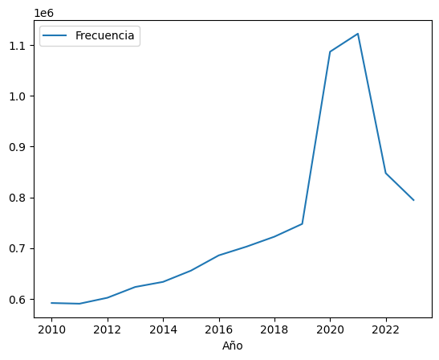

```python
df_año.plot()
```

## Elementos de una gráfica

[figure not shown]

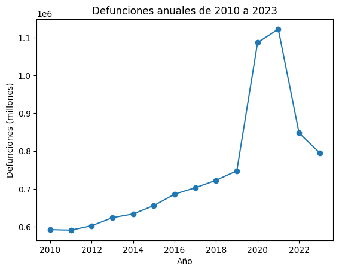

```python
df_año.plot(style='o-',
            legend=False,
            ylabel='Defunciones (millones)',
            title='Defunciones anuales de 2010 a 2023')
plt.show()
```

## Tipos de gráficas

Gráfica: codificación visual + tipos de datos + relaciones

Es un patrón común o convención para combinar codificaciones visuales o símbolos

Considerar:

- tipo de análisis
- mensaje a transmitir
- facilidad de generación
- facilidad de interpretación
- familiaridad del público con el gráfico

Revisemos las opciones en la documentación de [pandas.DataFrame.plot](https://pandas.pydata.org/docs/reference/api/pandas.DataFrame.plot.html)

[figure not shown]

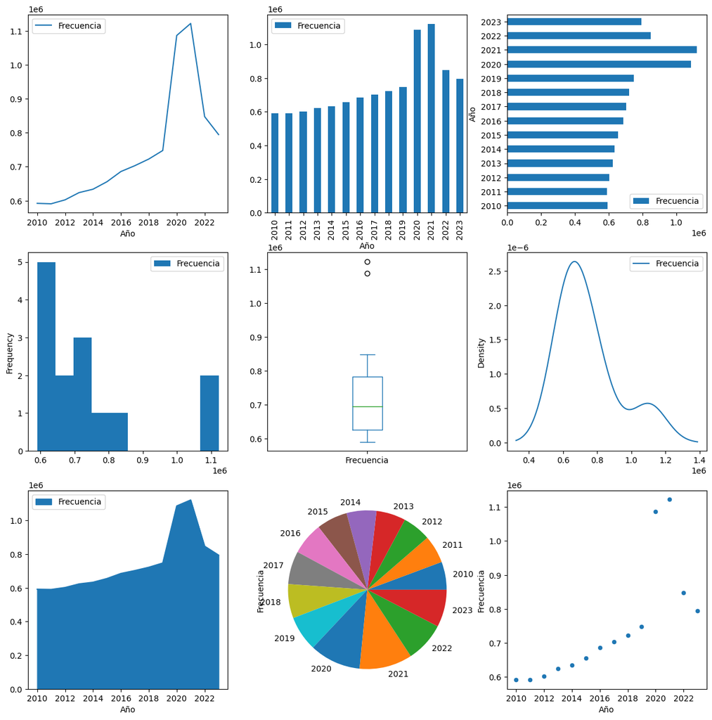

```python
fig, axes = plt.subplots(3, 3, figsize=(15, 15))
df_año.plot.line(ax=axes[0,0])
df_año.plot.bar(ax=axes[0,1])
df_año.plot.barh(ax=axes[0,2])
df_año.plot.hist(ax=axes[1,0])
df_año.plot.box(ax=axes[1,1])
df_año.plot.kde(ax=axes[1,2])
df_año.plot.area(ax=axes[2,0])
df_año.plot.pie(ax=axes[2,1], subplots=True, legend=False)
df_año.reset_index().plot.scatter(ax=axes[2,2], x='Año', y='Frecuencia')
plt.show()
```

## Codificación visual

Se representa la información de manera gráfica mediante elementos visuales

Datos → Elementos visuales

Elementos visuales: colores, formas, tamaños y posiciones, etc.

La codificación depende de los datos, sus tipos y la jerarquía interna. Generar codificación:

- Determina variables y tipo de dato
- Jerarquiza variables
- Asigna mapeo

**Elementos visuales posicionales**

- Puntos:
  - dos escalas cuantitativas
  - mediciones independientes
- Líneas:
  - una de las escalas es secuencial, por ejemplo tiempo
  - resaltar forma o cambios
  - líneas suaves y continuas indican proceso continuo
  - usa puntos y líneas para resaltar mediciones
  - NO usar para categóricos
- GráficaGráficaBarras:
  - Representar y comparar valores en categorías
  - Series de tiempo si interesa comparación entre puntos
  - Siempre empieza en cero (si eje no empieza en cero usar puntos)

**Elementos visuales retinales:**

- Tamaño, orientación, tono, saturación, forma y textura

## Gráfica: Defunciones por grupo de edad

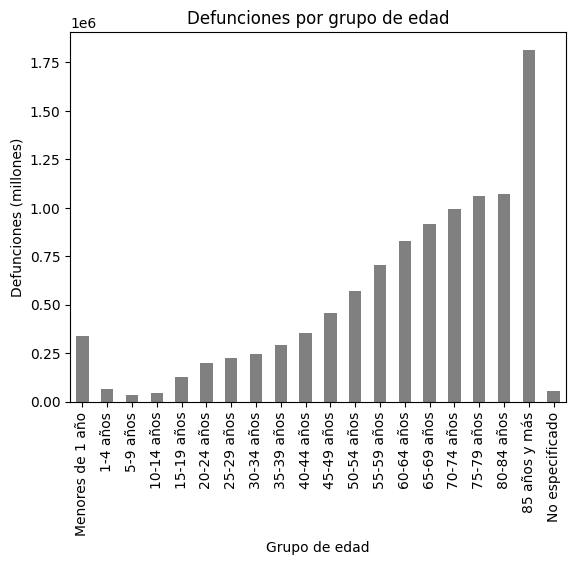

```python
df_edad = df[['Edad','Frecuencia']].groupby('Edad').sum()
df_edad.plot.bar(
            color='grey',
            legend=False,
            xlabel='Grupo de edad',
            ylabel='Defunciones (millones)',
            title='Defunciones por grupo de edad'
            )
plt.show()
```

¿Cuales son las codificaciones visuales usadas en las siguientes gráficas?

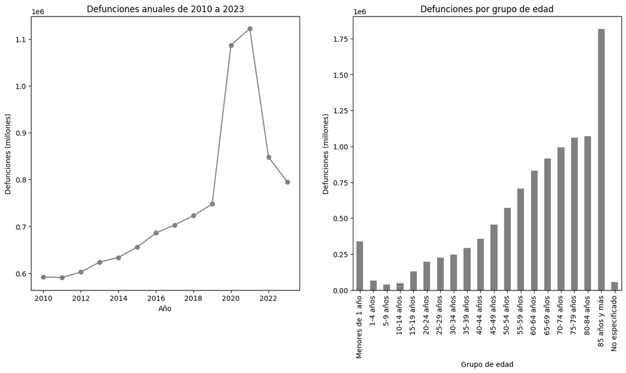

```python
fig, axes = plt.subplots(1, 2, figsize=(15, 7))
# Año
df_año.plot(ax=axes[0],
            style='o-',
            color='grey',
            legend=False,
            ylabel='Defunciones (millones)',
            title='Defunciones anuales de 2010 a 2023')
# Edad
df_edad.plot.bar(ax=axes[1],
            color='grey',
            legend=False,
            xlabel='Grupo de edad',
            ylabel='Defunciones (millones)',
            title='Defunciones por grupo de edad'
            )
plt.show()
```

## Gráfica: Sexo vs Frecuencia

En este caso usaremos una gráfica de pay, por ser la representación más común. Otra opción es una barra apilada.

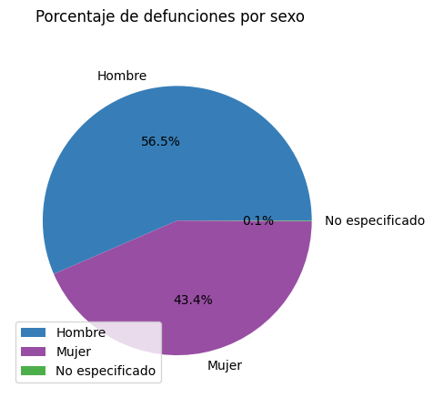

```python
df_sexo = df[['Sexo','Frecuencia']].groupby('Sexo').sum()
color_dict = {'Hombre':'#377eb8', 'Mujer':'#984ea3', 'No especificado':'#4daf4a'}
df_sexo.plot.pie(
            subplots=True,
            colors=color_dict.values(),
            title='Porcentaje de defunciones por sexo',
            ylabel='',
            autopct='%1.1f%%'
            )
plt.show()
```

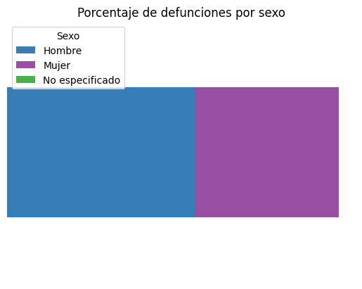

```python
ax = df_sexo.transpose().plot.barh(
            stacked=True,
            color=color_dict,
            title='Porcentaje de defunciones por sexo',
            ylabel=''
            )
ax.spines['top'].set_visible(False)
ax.spines['right'].set_visible(False)
ax.spines['bottom'].set_visible(False)
ax.spines['left'].set_visible(False)
ax.set_xticks([])
ax.set_yticks([])
plt.show()
```

**Elementos visuales retinales:**

- Tamaño, orientación, tono, saturación, forma y textura

[figure not shown]

## Gráfica: Diagnóstico vs Frecuencia

```
array([<Axes: >], dtype=object)
```

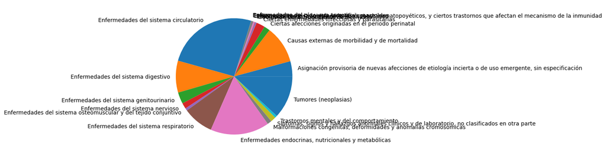

```python
df_diag = df[['Diagnostico','Frecuencia']].groupby('Diagnostico').sum()
df_diag.plot.pie(subplots=True, legend=False, ylabel='')
```

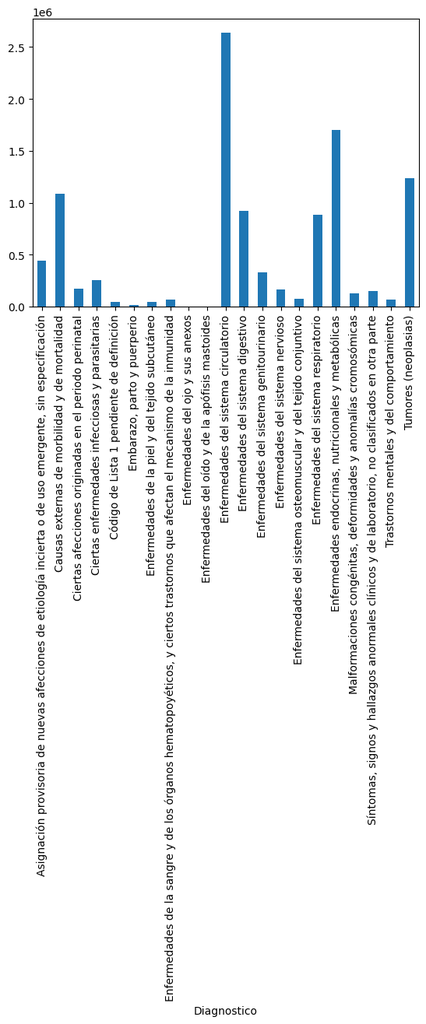

```python
df_diag.plot.bar(legend=False)
```

Problemas:

- Muchas categorías (21 categorías)
- Nombres largos de categoría (121 caracteres)
- Diferencias de magnitud (2639739 vs 253)

Veamos por porcentaje

```python
(df_diag/df_diag.sum()*100).sort_values(by='Frecuencia', ascending=False)
```

| Diagnostico | Frecuencia |
| --- | --- |
| Enfermedades del sistema circulatorio | 25.361017 |
| Enfermedades endocrinas, nutricionales y metabólicas | 16.350442 |
| Tumores (neoplasias) | 11.892409 |
| Causas externas de morbilidad y de mortalidad | 10.403580 |
| Enfermedades del sistema digestivo | 8.851063 |
| Enfermedades del sistema respiratorio | 8.491276 |
| Asignación provisoria de nuevas afecciones de etiología incierta o de uso emergente, sin especificación | 4.218146 |
| Enfermedades del sistema genitourinario | 3.180288 |
| Ciertas enfermedades infecciosas y parasitarias | 2.416827 |
| Ciertas afecciones originadas en el periodo perinatal | 1.642038 |
| Enfermedades del sistema nervioso | 1.608509 |
| Síntomas, signos y hallazgos anormales clínicos y de laboratorio, no clasificados en otra parte | 1.460276 |
| Malformaciones congénitas, deformidades y anomalías cromosómicas | 1.189088 |
| Enfermedades del sistema osteomuscular y del tejido conjuntivo | 0.684959 |
| Enfermedades de la sangre y de los órganos hematopoyéticos, y ciertos trastornos que afectan el mecanismo de la inmunidad | 0.657194 |
| Trastornos mentales y del comportamiento | 0.639632 |
| Enfermedades de la piel y del tejido subcutáneo | 0.412176 |
| Código de Lista 1 pendiente de definición | 0.409707 |
| Embarazo, parto y puerperio | 0.123445 |
| Enfermedades del oído y de la apófisis mastoides | 0.005495 |
| Enfermedades del ojo y sus anexos | 0.002431 |

Posibles soluciones:

- Ordenar por frecuencia.
  - Desventaja: perdida información
- Modificar etiquetas.
  - Desventaja: perdida información
- Agrupar baja frecuencia.
  - Desventaja: perdida información y patrones
  - Máximo diéz categorias o un orden de magnitud de diferencia

```python
df_diag = df_diag.sort_values(by='Frecuencia', ascending=False)

diag_corto = {
    'Ciertas enfermedades infecciosas y parasitarias':'Infecciosas y parasitarias',
    'Tumores (neoplasias)':'Tumores',
    'Enfermedades de la sangre y de los órganos hematopoyéticos, y ciertos trastornos que afectan el mecanismo de la inmunidad':'Sangre e inmunes',
    'Enfermedades endocrinas, nutricionales y metabólicas':'Endocrinas y metabólicas',
    'Trastornos mentales y del comportamiento':'Mentales',
    'Enfermedades del sistema nervioso':'Sistema nervioso',
    'Enfermedades del ojo y sus anexos':'Ojo',
    'Enfermedades del oído y de la apófisis mastoides':'Oído',
    'Enfermedades del sistema circulatorio':'Circulatorio',
    'Enfermedades del sistema respiratorio':'Respiratorio',
    'Enfermedades del sistema digestivo':'Digestivo',
    'Enfermedades de la piel y del tejido subcutáneo':'Piel',
    'Enfermedades del sistema osteomuscular y del tejido conjuntivo':'Osteomuscular',
    'Enfermedades del sistema genitourinario':'Genitourinario',
    'Embarazo, parto y puerperio':'Embarazo',
    'Ciertas afecciones originadas en el periodo perinatal':'Perinatal',
    'Malformaciones congénitas, deformidades y anomalías cromosómicas':'Malformaciones',
    'Síntomas, signos y hallazgos anormales clínicos y de laboratorio, no clasificados en otra parte':'Anormales',
    'Causas externas de morbilidad y de mortalidad':'Externas',
    'Asignación provisoria de nuevas afecciones de etiología incierta o de uso emergente, sin especificación':'Emergente',
    'Código de Lista 1 pendiente de definición':'Pendiente'
    }
df_diag = df_diag.rename(diag_corto)

df_diag.plot.bar(
            color='grey',
            legend=False,
            xlabel='Diagnóstico',
            ylabel='Defunciones (millones)',
            title='Defunciones por diagnóstico'
)

plt.show()
```

[output not shown]

```python
df_diag.plot.pie(subplots=True, legend=False, ylabel='')
```

[output not shown]

Quitando diagnósticos de baja frecuencia

```python
n_small = 8

otras = df_diag[n_small-1:].sum()
otras.name = 'Otras'

df_diag_res = df_diag[0:n_small-1].append(otras)
df_diag_res


dic_color = {'Otras':'#8dd3c7', 'Circulatorio':'#ffffb3', 'Endocrinas y metabólicas':'#bebada',
             'Tumores':'#fccde5', 'Externas':'#80b1d3', 'Digestivo':'#fdb462',
             'Respiratorio':'#b3de69', 'Emergente':'#fb8072'}
df_diag_res.plot.pie(subplots=True, legend=False, ylabel='')
plt.show()
```

[output not shown]

## Selección de colores

- Diseña en blanco y negro
- Usa colores poco intensos o desaturado
- Evita colores sólidos #ffffff
- Usa colores vibrantes para resaltar
- Selecciona color según el tipo de variable (secuencial, divergente, cíclico, cualitativa)
- Considera el impacto emocional y asociaciones culturales
- Considera a las personas daltónicas
- Usa solo uno o dos colores (excepto que sean codificación de variable)
- Cuidado con los ajustes logarítmicos
- Evita usar el mismo color para representar variables distintas

Usen https://colorbrewer2.org/

[figure not shown]

```python
# Obtener tabla pivote
df_ad = df.pivot_table(index='Año', columns='Diagnostico',
                       values='Frecuencia', aggfunc=sum, fill_value=0)
# Acortar nombres de diagnósticos
df_ad = df_ad.rename(diag_corto, axis=1)
# Ordenar de mayor a menor
df_ad.loc['total']= df_ad.sum()
df_ad = df_ad.sort_values(by='total', axis=1, ascending=False)
df_ad = df_ad.drop('total')
# Sumar baja frecuencia
n_small = 8
otras = df_ad.iloc[:,n_small-1:].sum(axis=1)
df_ad = df_ad.iloc[:,0:n_small-1]
df_ad.insert(0, 'Otras', otras)
df_ad
# graficar
dic_color = {'Otras':'#8dd3c7', 'Circulatorio':'#ffffb3', 'Endocrinas y metabólicas':'#bebada',
             'Tumores':'#fccde5', 'Externas':'#80b1d3', 'Digestivo':'#fdb462',
             'Respiratorio':'#b3de69', 'Emergente':'#fb8072'}
df_ad.plot.area(
            color=dic_color,
            xlabel='Año',
            ylabel='Defunciones (millones)',
            title='Defunciones por diagnóstico de 2010 a 2024'
            )
plt.show()
```

[output not shown]

## Visualización explicativa

¿Cuál es el mensaje qué se quiere transmitir?

Nota: estas solo son representaciónes visuales, para saber si es significativo es necesario hacer pruebas estadíasticas.

```python
# grafica área enfermedades
dic_color = {'Otras':'#8dd3c7', 'Circulatorio':'#ffffb3', 'Endocrinas y metabólicas':'#bebada',
             'Tumores':'#fccde5', 'Externas':'#80b1d3', 'Digestivo':'#fdb462',
             'Respiratorio':'#b3de69', 'Emergente':'#fb8072'}
df_ad.plot.area(
            color=dic_color,
            xlabel='Año',
            ylabel='Defunciones (millones)',
            title='Defunciones por diagnóstico de 2010 a 2024'
            )
plt.show()
```

[output not shown]

```python
dic_color = {'Otras':'#8dd3c7', 'Circulatorio':'#ffffb3', 'Endocrinas y metabólicas':'#bebada',
             'Tumores':'#fccde5', 'Externas':'#80b1d3', 'Digestivo':'#fdb462',
             'Respiratorio':'#b3de69', 'Emergente':'#fb8072'}
df_ad.divide(df_ad.sum(axis=1),axis=0) \
     .plot.area(
            color=dic_color,
            xlabel='Año',
            ylabel='Defunciones (porcentaje)',
            title='Porcentaje de defunciones por diagnóstico de 2010 a 2024'
            )
plt.show()
```

[output not shown]

```python
dic_color = {'Otras':'#999999', 'Circulatorio':'#a65628', 'Endocrinas y metabólicas':'#984ea3',
             'Tumores':'#f781bf', 'Externas':'#377eb8', 'Digestivo':'#ff7f00',
             'Respiratorio':'#4daf4a', 'Emergente':'#e41a1c'}
df_ad.plot.line(
            color=dic_color,
            xlabel='Año',
            ylabel='Defunciones (millones)',
            title='Defunciones por diagnóstico de 2010 a 2024'
            )
plt.show()
```

[output not shown]

```python
import seaborn as sns
# normalizar cada diagnóstico por el valor máximo
df_ad_norm = df_ad.drop('Emergente', axis=1)
df_ad_norm = df_ad_norm.divide(df_ad_norm.sum(axis=0),axis=1).transpose()
sns.heatmap(df_ad_norm, cmap='magma_r')
plt.title('Año con más defunciones por diagnóstico')
plt.show()
```

[output not shown]

Evaluar:

- ¿Qué tan bien se transmite el mensaje?
- ¿Qué tan entendible es la gráfica por el público?
- ¿Que ideas erroneas o engañosas transmite la gráfica?